# Logistic Regression, Stochastic Gradient Descent and Support Vector Machine

Authors: Huy Hoang Nguyen, Sanjay Pillay, Hao Wang and Wailun Chung  
(Southern Methodist University - USA)

### Citations are represented with prefix şş followed by reference link.

# Table of Contents:

## Part A. Introduction (From Lab 1)

### I. Business Understanding

## Part B. Minilab - Logistic Regression and Support Vector Machine

### III. Interpret Feature Importance

### IV. Interpret Support Vector

## Part C. Conclusion and Discussion

# Part A. Introduction

In this minilab, we will use different machine learning classification algorithms such as Logistic Regression and Support Vector Machine. We carry over the Business Understanding and Data Preparation from Lab 1 to this Minilab. More information related to Visualization and Data Preprocessing can be found in [Lab 1 - Visualization and Data Processing](https://hnguye01.github.io/DS7331/lab1_team_pms.html).

## I. Business Understanding

Kaggle dataset (https://www.kaggle.com/stefanoleone992/fifa-20-complete-player-dataset) *players_20.csv* is used in this lab. The dataset provides detailed information of all the **soccer players statistics** in various clubs of major soccer leagues in the world. The data is originally from the FIFA soccer game created by EA sports. This game estimates the abilities of the actual players and built the game according to the data. And the Kaggle dataset is scraped from www.sofifa.com, where the gaming data is collected. The data we used is last updated on Sept 19th 2019.

The dataset is important because the abilities of players is estimated from the actual players. FIFA is a very popular game and EA Sports is one of the largest sport video game developer. The player abilities estimate is quite accurate. Therefore, useful knowledge can be mined from the data for analyzing variety problems in the soccer industry. For example, wage analysis, player analysis, training strategy, budget analysis, sport gambling strategy plan can be performed using this dataset. Soccer has been a big industry which the market size is estimated to worth $488 billion in 2018 according to the Business Wire.

Some of the analyses we are interested in to performs are:

1. Run predictive model to predict wage from players abilities. We will select some features to run regression model. Also, we will try running PCA and regression model. To measure the effectiveness, we will use RMSE, MAE and R squared.
2. Run classification model to classify players position from the players ability. To validate our model, we will use accuracy, precision, F1 score and ROC.

We also intent to use the detailed game statistics from fbref.com. We can potential run analysis using the win/lose results from the real time data.

⏫ Table of Contents

şş Image captured from https://en.wikipedia.org/wiki/FIFA_20

[figure not shown]

## II. Data Preparation

In this subsection, Explonatory Data Analysis will be presented. We deal with missing values, divide the soccers players into 4 groups meaningfully as Defending (DEF, Forward (FWD), Midfield (MID) and Goal Keeper (GK) and show how we decide to arrive to our final cleaned dataset for our next step to study Logistic Regression and Support Vector Machine. We also use Stochastic Gradient Descent for the classification study.

```python
#All Python module imports
#https://pandas.pydata.org/docs/user_guide/index.html#user-guide
import pandas as pd #Pandas Dataframe module

import numpy as np
from math import pi
#scikit learn
#https://scikit-learn.org/stable/modules/classes.html#module-sklearn.linear_model
import sklearn as sl


import pycountry
import plotly.express as px

#https://seaborn.pydata.org
import seaborn as sns
import matplotlib.pyplot as plt

# os calls
import os

#Module for formating table for documentation
#https://pypi.org/project/tabulate/
from tabulate import tabulate

from IPython.display import display, Markdown

#Interactive mode
from IPython.core.interactiveshell import InteractiveShell
InteractiveShell.ast_node_interactivity = "all"
from IPython.display import Image

##minilab imports
from sklearn.model_selection import GridSearchCV as gridcv
from sklearn import preprocessing
from sklearn.feature_selection import SelectKBest, chi2
from sklearn.model_selection import StratifiedShuffleSplit
from sklearn.preprocessing import StandardScaler
from sklearn.linear_model import LogisticRegression
from sklearn import metrics as mt
from sklearn.metrics import plot_confusion_matrix
from sklearn.metrics import classification_report
from sklearn.svm import SVC
from sklearn.decomposition import PCA
from sklearn.metrics import confusion_matrix
from sklearn.metrics import f1_score, accuracy_score
```

Due to the large number of features we have created a csv file that will serve as a metadata file as follows  
1) File location: ../data/fifa20/data_desc.csv  
2) The Name column as the exact name that is in our original dataset file and we will use this to load the file.  
3) Description: The team has filled up the description of each feature describing it.  
4) Variable_cat: We use this to categorise related features for example 'Position' indicates all the features related to various position attirbutes.  
Using a metadata makes it easy in case we want to ignore certain attributes that are not relavant for our analysis by marking it as Ignore.

```python
##Globally set seed
np.random.seed(45)

#Read data explanation csv file maintained by project team
%time df_desc = pd.read_csv('../data/fifa20/data_desc.csv',usecols=['Name','Description','Statistics','Variable_cat'])
#display(Markdown(df_desc[['Name','Description','Variable_cat']].to_markdown()))

#All positional attributes, These are various field positions a players can playin with a players statisics in
#that position. These attributes are only for non-goalkeepers.
df_position_attr = df_desc[df_desc['Variable_cat']=='Position']['Name']

#All goalKeeper only attributes
df_gk_attr = df_desc[df_desc['Variable_cat']=='GK']['Name']

#All Technical attributes. Non GK players primary technical skills such as dribbling, curving etc.
df_technical_attr = df_desc[df_desc['Variable_cat']=='Technical']['Name']

#All mental attributes for all players
df_mental_attr = df_desc[df_desc['Variable_cat']=='Mental']['Name']

#All Attacking attributes  for all players
df_attacking_attr = df_desc[df_desc['Variable_cat']=='Attacking']['Name']

#All general Skill category attributes  for all players
df_skill_attr = df_desc[df_desc['Variable_cat']=='Skill']['Name']

#All Movement attributes  for all players
df_movement_attr = df_desc[df_desc['Variable_cat']=='Movement']['Name']

#All Power attributes  for all players
df_power_attr = df_desc[df_desc['Variable_cat']=='Power']['Name']

#All Defending attributes  for all players
df_defending_attr = df_desc[df_desc['Variable_cat']=='Defending']['Name']

# Sample code for future use to include adhoc columns
# Get all columns of player posiotion, you can do same for technical, Physical, GK etc
## l=df_gk_attr.append(pd.Series(['short_name','age','club']))
## df_gkplus_list from main object df_players = df_players[l]
```

```
CPU times: user 2.99 ms, sys: 863 µs, total: 3.85 ms
Wall time: 4.03 ms
```

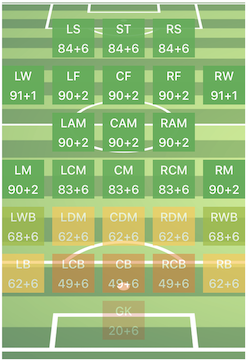

This image helps us understand various positions that a soccer players is assigned during a game. The feature **player_positions** represents multiple positions that a player can play in with a comma seperate value, the very first item in that list has a preferred field position of the player. The **team_position** is the current positon that the player is being used in the team. For our analysis we will use the players preferred positon.

```python
#Data mining read csv file
#Using data set: https://www.kaggle.com/stefanoleone992/fifa-20-complete-player-dataset#players_15.csv
#we will read only data we are intrested in
cols_to_read = df_desc['Name'].loc[df_desc.Variable_cat != 'Ignore']
%time df_players = pd.read_csv('../data/fifa20/players_20.csv',usecols=cols_to_read)
```

```
CPU times: user 195 ms, sys: 38.2 ms, total: 233 ms
Wall time: 239 ms
```

```python
df_players['preferred_position'] = df_players.player_positions.str.split(',').apply(lambda x: x[0])
```

#### team_postion

We see the team_position has 241 empty values. Since we do not intent to use team_position nor nation_positon in our analysis, we will drop it.

```python
df_players = df_players.drop(columns=['nation_position','team_position'])
```

#### Get total goal keepers vs regular players.

It is critical to properly identify goal keepers vs rest of the other players as many attributes are specific to either goal keepers or regular players. We will be using this a lot in our data cleanup and analysis later.

```python
#goal keeper count
df_players[df_players['preferred_position'] =='GK'].shape

#regular player count
df_players[df_players['preferred_position'] !='GK'].shape
```

```
(2036, 86)
```

```
(16242, 86)
```

#### Categorizing to four player positions

1. Defending (DEF)
2. Forward (FWD)
3. Midfield (MID)
4. Goal Keeper (GK)

We will use this later to predict player positions

```python
#df_players.preferred_position.value_counts()
df_players['preferred_position_cat'] = df_players.preferred_position.map({

        'CB': 'DEF',
        'ST': 'FWD',
        'CM': 'MID',
        'GK': 'GK',
       'CDM': 'DEF',
        'RB': 'DEF',
        'LB': 'DEF',
       'CAM': 'FWD',
        'RM': 'MID',
        'LM': 'MID',
        'LW': 'FWD',
        'RW': 'FWD',
        'CF': 'FWD',
       'LWB': 'DEF',
        'RWB': 'DEF'
    })
```

```python
df_players.preferred_position_cat.value_counts()
```

```
DEF    7362
FWD    4588
MID    4292
GK     2036
Name: preferred_position_cat, dtype: int64
```

#### Wages

```python
# 1. wages, The fields wage_eur and value_eur have about 240 and 250 vales respectively set to 0 (Analyzed in
# section B), we will set these values to the respective median values
#df_players['wage_eur'].median()
df_players['wage_eur'].replace(0,df_players['wage_eur'].median(), inplace=True)
```

```python
#df_players['value_eur'].median()
df_players['value_eur'].replace(0,df_players['value_eur'].median(), inplace=True)
```

#### Body type

```python
df_players['body_type'].replace({'Shaqiri': 'Normal', 'Akinfenwa': 'Normal'
                                , 'C. Ronaldo': 'Normal', 'PLAYER_BODY_TYPE_25': 'Normal'
                                , 'Neymar': 'Normal', 'Courtois': 'Normal','Messi':'Normal'}, inplace=True)
#df_players['body_type'].value_counts()
```

#### Refactor position features [Object to discrete]

The position features inculdes year over improvement / decrement. For example a player in st (Striker) position with a value of 89+2 is basically 89 with an increase (- would indicate decrease) of 2 from last year. Since we will not be doing any year over analysis, we will remove the suffix for these columns = ['ls','st','rs','lw','lf','cf','rf', 'rw','lam','cam','ram', 'lm','lcm','cm','rcm','rm','lwb','ldm', 'cdm','rdm', 'rwb','lb','lcb', 'cb','rcb','rb']

```python
# 4. Refactor position features based on bullet 1 above to remove the +/- incriment/decriment and preseve
# the current years score
df_players1 = df_players[df_position_attr].apply(lambda x: x.str.slice(start=0,stop=2),
                          axis=1, result_type='broadcast')
df_players[df_position_attr] = df_players1
```

#### Dealing with missing values

The player positional features mentioned above and the skills features ['pace','shooting', 'passing','dribbling', 'defending','physic'] have a total of 2036 missing values. We see that all of them are categorized to play in the GK position (player_positions="GK", Goal Keeper). We will set these values to zero.

#### Goal Keeper specific attributes

The following features ['gk_diving','gk_handling','gk_kicking','gk_reflexes', 'gk_speed','gk_positioning'] are specific to goalkeepers. We see a total of 16242 mising values, which corrosponds to the non goalkeeper or regular positional players. We will set these values to zero. Also there are duplicate columns representing these same attributes which we will ignore ['goalkeeping_diving', 'goalkeeping_handling', 'goalkeeping_kicking', 'goalkeeping_positioning', 'goalkeeping_reflexes']

```python
df_players.info(verbose=True, null_counts=True)
```

```
<class 'pandas.core.frame.DataFrame'>
RangeIndex: 18278 entries, 0 to 18277
Data columns (total 87 columns):
 #   Column                      Non-Null Count  Dtype
---  ------                      --------------  -----
 0   sofifa_id                   18278 non-null  int64
 1   short_name                  18278 non-null  object
 2   age                         18278 non-null  int64
 3   dob                         18278 non-null  object
 4   height_cm                   18278 non-null  int64
 5   weight_kg                   18278 non-null  int64
 6   nationality                 18278 non-null  object
 7   club                        18278 non-null  object
 8   overall                     18278 non-null  int64
 9   potential                   18278 non-null  int64
```

[output cut: 79 more lines]

```python
# 5, 6. we will set all the other missing variables to 0 as explained above in bullet 4 & 5
df_players.fillna(0, inplace=True)
```

#### Data type conversion

We will first convert our continuous features.

```python
# changing the continuous values to be float64
continuous_features = ['height_cm','weight_kg','value_eur', 'wage_eur']
df_players[continuous_features] = df_players[continuous_features].astype(np.float64)
```

sofifa_id is converted to object as it is a nominal

```python
df_players['sofifa_id'] = df_players['sofifa_id'].astype(np.object)
```

We will convert object features that are discrete to integer

```python
#change the position features from object to int64 as they we manipulated to remove +/- based on step 1
df_players[df_position_attr] = df_players[df_position_attr].astype(np.int64)
#df_players.info(verbose=True, null_counts=True)
```

#### **Dataset Summary after cleanup**

Data types: float64(17), int64(60), object(10)  
No missing values

#### Our cleaned dataset copy with all players

```python
# Our cleaned dataset **copy** is df_players_cleaned
df_players_cleaned = df_players.copy()
df_players_cleaned.shape
```

```
(18278, 87)
```

#### We will also have a **view** for goal keepers as df_players_gk

```python
#We will now also have **views** for goal keepers in df_players_gk and regular
df_players_gk = df_players_cleaned[df_players_cleaned['player_positions'] =='GK']
df_players_gk.shape
```

```
(2036, 87)
```

#### We will also have a **view** for non-goal keepers as df_players_regular

```python
df_players_regular = df_players_cleaned[df_players_cleaned['player_positions'] !='GK']
df_players_regular.shape
```

```
(16242, 87)
```

⏫ Table of Contents

# Part B. Minilab - Logistic Regression and Support Vector Machine

## I. Create Models

In this section, we create different logistic regression (LR) and support vector machine (SVM) models for the classification task involved with FIFA dataset and assess how well each model performs (use 80/20 training/testing split). We also adjust parameters of the models to make them more accurate. Although we have a mid size dataset, we also run the SGD model just to evaluate its time performance in converging to the minimum.

In our analysis, we are classifying players' position from the fifa dataset. Below, we make a copy of our cleaned dataset into players_X which includes all our regressor variables that we identified in Lab1. There are a total of 31 features including players mental, attacking, skills, movements, defending, power, height and weight attributes. The actual players' position are in players_y dataframe. We will scale all the features to zero mean and 1 Std Deviation into X_players_scaled and use this for our analysis.

```python
df_pred_pos=df_players_cleaned.copy()
l=df_mental_attr.append(df_attacking_attr).append(df_skill_attr).append(df_movement_attr).append(df_power_attr).append(df_defending_attr)
l=l.append(pd.Series(['height_cm','weight_kg']))

l.count()
players_X = df_pred_pos[l].values

players_y = df_pred_pos['preferred_position_cat'].values

df = df_pred_pos[l]
##Scale the transformed data
scl_obj = StandardScaler()
scl_obj.fit(players_X)
X_players_scaled = scl_obj.transform(players_X)
```

```
31
```

```
StandardScaler()
```

Let's take a look at the current class distributions.

```
Total Records 18278
Total Classes: 4
Class Gini Index 0.7072144368980946
Smallest Class Id: GK Records: 2036
Largest Class Id: DEF Records: 7362
Accuracy when Guessing: 25.0 %
     preferred_position_cat  Percentage
DEF                    7362    0.402779
FWD                    4588    0.251012
MID                    4292    0.234818
GK                     2036    0.111391
```

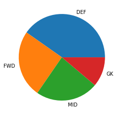

```python
#Check class distribution
%matplotlib inline

# Adapted from:
# https://www.featureranking.com/tutorials/machine-learning-tutorials/information-gain-computation/
def gini_index(y):
    probs = pd.value_counts(y,normalize=True)
    return 1 - np.sum(np.square(probs))

def plot_class_dist(y):
    class_ct = len(np.unique(y['preferred_position_cat']))
    vc = pd.value_counts(y['preferred_position_cat'])
    print('Total Records', len(y['preferred_position_cat']))
    print('Total Classes:', class_ct)
    print('Class Gini Index', gini_index(y['preferred_position_cat']))
    print('Smallest Class Id:',vc.idxmin(),'Records:',vc.min())
    print('Largest Class Id:',vc.idxmax(),'Records:',vc.max())
    print('Accuracy when Guessing:', np.round( (1 / len(np.unique(y['preferred_position_cat']))) * 100, 2), '%')

    position_counts = pd.DataFrame(df_pred_pos['preferred_position_cat'].value_counts())
    position_counts['Percentage'] = position_counts['preferred_position_cat']/position_counts.sum()[0]
    print(position_counts)
    plt.figure(figsize=(4,4))
    plt.pie(position_counts['Percentage'],labels = ['DEF', 'FWD', 'MID', 'GK']);


plot_class_dist(df_pred_pos)
```

We see some imbalance in the classifications, we keep it as is but we will try to evaluate various rebalance stratergies in Logistic regression to see if there is any impact on accuracy.  
We prepare our test / train split using a 80/20 split. We chose to use StratifiedShufflesplit to ensures that there will be selection in similar proportion of classes from each group and omit sampling bias.

```python
# Lets create the test/train 80/20 split indexes using stratifiedshuffle split due to
# some imbalance in the classes as seen above
sss = StratifiedShuffleSplit(n_splits=1, test_size=0.2, random_state=0)
train_index, test_index = next(sss.split(X_players_scaled, players_y))
X_train = X_players_scaled[train_index]
y_train = players_y[train_index]
X_test = X_players_scaled[test_index]
y_test = players_y[test_index]
```

```python
def evaluate_model_performance(model_name, params, clf, X_train, y_train, X_test, y_test, nCV = 10):
    ##Create a 70%/30% split using stratified shuffle split in order to maintain ration
    #grid = gridcv(clf, params, cv=3,scoring='f1_micro')
    # We prepare the grid search object
    grid = gridcv(clf, params, cv=nCV,scoring='accuracy', refit=True )
    grid.fit(X_train, y_train)
    model_stat =  pd.DataFrame()
    model_stat['model_name'] =[str(model_name)]

    res = grid.cv_results_

    #grid.cv_results_.keys()
    res.keys()
    res['params']
    grid_scr = pd.DataFrame()
    grid_scr['params'] = res['params']
    grid_scr['mean_test_score'] = res['mean_test_score']
    grid_scr = pd.DataFrame(grid_scr)
    #print(grid_scr)

    grid_scr.plot.bar(color='grey',figsize=(10,6))
    plt.ylabel('Accuracy')
    plt.xlabel('Params')
    plt.grid(color='blue', linestyle='--', linewidth=0.5)
    plt.ylim(0.5,.95)

    print("Best parameters set found on development set:")
    print()
    print(grid.best_params_)
    #model_stat['score'] = [grid.best_score_]
    print()
    print("Grid scores on development set:")
    print()
    means = res['mean_test_score']
    stds = res['std_test_score']
    for mean, std, params in zip(means, stds, res['params']):
        print("%0.5f (+/-%0.03f) for %r"
              % (mean, std * 2, params))
    print()

    print("Detailed classification report:")
    print()
    print("The model is trained on the full development set.")
    print("The scores are computed on the full evaluation set.")
    print()
    #build CM using test/Train
    y_true, y_pred = y_test, grid.predict(X_test)
    #y_pred
    print(classification_report(y_true, y_pred, target_names=['DEF', 'FWD', 'GK','MID']))
    s = classification_report(y_true, y_pred, target_names=['DEF', 'FWD', 'GK','MID'])
    model_stat['CM'] = s
    plot_confusion_matrix(grid, X_test,y_test,cmap=plt.cm.Blues,values_format='d')
    model_stat['time_refit'] = [grid.refit_time_]
    model_stat['model_param'] = [str(grid.best_params_)]
    model_stat['weighted_f1_score']=round(f1_score(y_true, y_pred, average='weighted'),2)
    #model_stat['accuracy']=accuracy_score(y_true, y_pred)
    plt.grid(b=None);
    print()
    return model_stat
```

We will use model_stats to hold each model statistics for final evaluation.

```python
#We will store each model performace numCVs=10stats in this dataframe
model_stats = pd.DataFrame()
numCVs=10
```